# Unit 03: Probability

Instructor: Dr. Md Mutasim Billah

# Resources

## Handouts

- Download the Unit 03 Handout: Probability before class and bring it with you.
- I will continue to post additional handouts as we progress through the course. Please watch for **Canvas Announcements** when a new handout becomes available.
- It is very important that you **bring the appropriate handout to class regularly**, either as a printed copy or on your writing device.

## Practice Problems

- **Practice Problems (PP)** are essential for strengthening your understanding, building confidence, and exploring the concepts covered in class.
- The **Unit 03 Practice Problems** are available under the **Practice Problems** tab on the course website. The solutions are provided in Canvas.
- Complete the relevant Practice Problems as we progress through the unit.
- Make sure you have completed and reviewed the Practice Problems **before attempting the corresponding HW assignment**.

# Probability

## Class Notes

- Live class lecture notes
- I usually post the class notes on Canvas by the end of the day. If you don’t see it, shoot me an email next day!

## Coin Toss Applet

- [Rossman/Chance Coin Tossing Simulation](https://www.rossmanchance.com/applets/2021/oneprop/OneProp.htm)

## Interpretation of Probability

- **Examples:**
  - “The chance of getting 1 when rolling a die is $1/6 = 16.7\%$.”
  - Meaning: If we roll a die many times under the same conditions, we would get 1 roughly $16.7\%$ of the time.
  - “The chance that a light bulb lasts longer than 2 years is $72\%$.”
  - Meaning: If we turn on many light bulbs under the same conditions, about $72\%$ of them would last longer than 2 years.

## Axioms of Probability

- The axioms of probability are properties that we intuitively expect a probability to have.
- All probability theory is built on these axioms.
- The mathematical foundations of probability, including these axioms, were laid out by **Andrey Kolmogorov in 1933**.

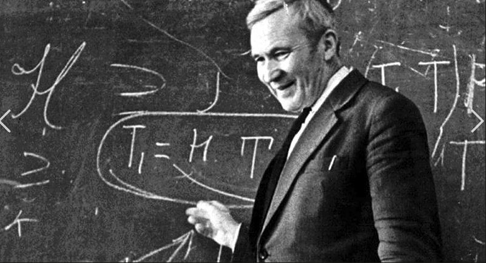